# Module 2 Homework: Chapter 3 Exercises, Problems 9, 10, and 14

## Ryan Waterman, 7/15/25

## Problem 9

This question involves the use of multiple linear regression on the Auto data set.

This dataset was used in the 1983 American Statistical Association Exposition. It includes gas mileage, horsepower, and other information for 392 vehicles.

```python
# Import necessary libraries
import pandas as pd
import statsmodels.api as sm
import warnings
warnings.filterwarnings('ignore')
```

## Part A

Produce a scatterplot matrix which includes all of the variables in the data set.

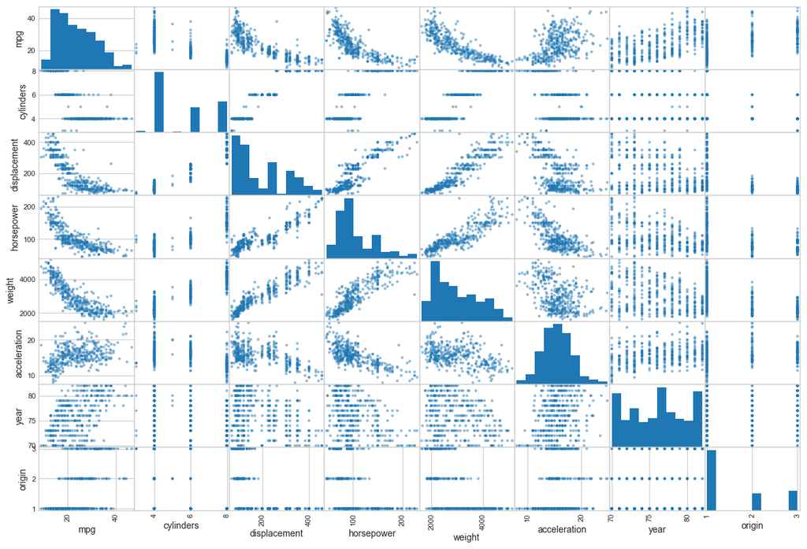

```python
# Load the dataset and remove nulls and N/A values
auto = pd.read_csv('./data/Auto.csv')
auto.dropna(axis=0, how='any')
auto = auto[auto['horsepower'] != '?']
auto['horsepower'] = auto['horsepower'].astype('int64')

# Create a scatter matrix
pd.plotting.scatter_matrix(auto, figsize=(15,10));
```

## Part B

Compute the matrix of correlations between the variables using the DataFrame.corr() method.

```python
quantitative = auto.describe().columns
auto[quantitative].corr()
```

|  | mpg | cylinders | displacement | horsepower | weight | acceleration | year | origin |
| --- | --- | --- | --- | --- | --- | --- | --- | --- |
| mpg | 1.000000 | -0.777618 | -0.805127 | -0.778427 | -0.832244 | 0.423329 | 0.580541 | 0.565209 |
| cylinders | -0.777618 | 1.000000 | 0.950823 | 0.842983 | 0.897527 | -0.504683 | -0.345647 | -0.568932 |
| displacement | -0.805127 | 0.950823 | 1.000000 | 0.897257 | 0.932994 | -0.543800 | -0.369855 | -0.614535 |
| horsepower | -0.778427 | 0.842983 | 0.897257 | 1.000000 | 0.864538 | -0.689196 | -0.416361 | -0.455171 |
| weight | -0.832244 | 0.897527 | 0.932994 | 0.864538 | 1.000000 | -0.416839 | -0.309120 | -0.585005 |
| acceleration | 0.423329 | -0.504683 | -0.543800 | -0.689196 | -0.416839 | 1.000000 | 0.290316 | 0.212746 |
| year | 0.580541 | -0.345647 | -0.369855 | -0.416361 | -0.309120 | 0.290316 | 1.000000 | 0.181528 |
| origin | 0.565209 | -0.568932 | -0.614535 | -0.455171 | -0.585005 | 0.212746 | 0.181528 | 1.000000 |

Of this correlation matrix, the highest correlation is between displacement and cylinders, while the lowest is between year and origin.

## Part C

Use the sm.OLS() function to perform a multiple linear regression with mpg as the response and all other variables except name as the predictors. Use the summarize() function to print the results. Comment on the output. For instance:

1. Is there a relationship between the predictors and the response? Use the anova_lm() function from statsmodels to answer this question.
2. Which predictors appear to have a statistically significant relationship to the response?
3. What does the coefficient for the year variable suggest?

### Sub-Part 1

```python
y = auto['mpg']
predictors = quantitative.drop('mpg')
x = sm.add_constant(auto[predictors])
model = sm.OLS(y, x, data=auto).fit()
print(model.summary())
```

```
                            OLS Regression Results
==============================================================================
Dep. Variable:                    mpg   R-squared:                       0.821
Model:                            OLS   Adj. R-squared:                  0.818
Method:                 Least Squares   F-statistic:                     252.4
Date:                Fri, 18 Jul 2025   Prob (F-statistic):          2.04e-139
Time:                        17:06:05   Log-Likelihood:                -1023.5
No. Observations:                 392   AIC:                             2063.
Df Residuals:                     384   BIC:                             2095.
Df Model:                           7
Covariance Type:            nonrobust
================================================================================
                   coef    std err          t      P>|t|      [0.025      0.975]
--------------------------------------------------------------------------------
const          -17.2184      4.644     -3.707      0.000     -26.350      -8.087
cylinders       -0.4934      0.323     -1.526      0.128      -1.129       0.142
displacement     0.0199      0.008      2.647      0.008       0.005       0.035
horsepower      -0.0170      0.014     -1.230      0.220      -0.044       0.010
weight          -0.0065      0.001     -9.929      0.000      -0.008      -0.005
acceleration     0.0806      0.099      0.815      0.415      -0.114       0.275
year             0.7508      0.051     14.729      0.000       0.651       0.851
origin           1.4261      0.278      5.127      0.000       0.879       1.973
==============================================================================
Omnibus:                       31.906   Durbin-Watson:                   1.309
Prob(Omnibus):                  0.000   Jarque-Bera (JB):               53.100
Skew:                           0.529   Prob(JB):                     2.95e-12
Kurtosis:                       4.460   Cond. No.                     8.59e+04
==============================================================================

Notes:
[1] Standard Errors assume that the covariance matrix of the errors is correctly specified.
[2] The condition number is large, 8.59e+04. This might indicate that there are
strong multicollinearity or other numerical problems.
```

**An R<sup>2</sup> value of 0.821 indicates that 82.1% of the variability in the dataset can be explained by the model. The t-values associated with the year, origin, and weight predictors indicate that there is a significant relationship between these predictors and mpg. Additionally, the p-values associated with the t-statistic are less than 0.05, further supporting the claim that there is a significant relationship between these predictors and mpg. To further analyze these relationships, let's perform both type 1 and type 2 ANOVA tests.**

### Sub-Part 2

```python
from ISLP.models import ModelSpec as MS
```

#### Type 1 ANOVA

```python
# LINK TO REFERENCE: https://github.com/statsmodels/statsmodels/issues/8241
design = MS(predictors)
# THIS WAS FOUND HERE: https://islp.readthedocs.io/en/latest/models/spec.html
design.fit_transform(auto)
anova = sm.stats.anova_lm(*[sm.OLS(y, D).fit() for D in design.build_sequence(auto, anova_type='sequential')])
anova.index = design.names

anova
```

|  | df_resid | ssr | df_diff | ss_diff | F | Pr(>F) |
| --- | --- | --- | --- | --- | --- | --- |
| intercept | 391.0 | 23818.993469 | 0.0 | NaN | NaN | NaN |
| cylinders | 390.0 | 9415.910391 | 1.0 | 14403.083079 | 1300.683788 | 2.806569e-126 |
| displacement | 389.0 | 8342.566366 | 1.0 | 1073.344025 | 96.929329 | 1.442524e-20 |
| horsepower | 388.0 | 7939.158297 | 1.0 | 403.408069 | 36.430140 | 3.700154e-09 |
| weight | 387.0 | 6963.433344 | 1.0 | 975.724953 | 88.113748 | 5.378297e-19 |
| acceleration | 386.0 | 6962.467273 | 1.0 | 0.966071 | 0.087242 | 7.678720e-01 |
| year | 385.0 | 4543.347025 | 1.0 | 2419.120249 | 218.460900 | 1.794078e-39 |
| origin | 384.0 | 4252.212530 | 1.0 | 291.134494 | 26.291171 | 4.665681e-07 |

**The type 1 ANOVA sequentially steps through the predictors and compares the response of each new predictor in the sequence to the previous. This is not helpful for determining the relationship between the response and predictors, as the order of the predictors in the sequence could skew their resulting response indication. A Type 2 ANOVA will be better suited for this application, as it is not dependent on the order of the predictors and assumes the predictor variables have no interaction. This will explicitly identify the predictors that have the most effect on the response.**

#### Type 2 ANOVA

```python
# CODE REFERENCE FOUND HERE: https://islp.readthedocs.io/en/latest/models/anova.html
dfs = []
for d in design.build_sequence(auto, anova_type='drop'):
    dfs.append(sm.stats.anova_lm(sm.OLS(y,d).fit(), model).iloc[1:])
df = pd.concat(dfs)
df.index = design.names
df
```

|  | df_resid | ssr | df_diff | ss_diff | F | Pr(>F) |
| --- | --- | --- | --- | --- | --- | --- |
| intercept | 384.0 | 4252.21253 | 1.0 | 152.205951 | 13.745100 | 2.401841e-04 |
| cylinders | 384.0 | 4252.21253 | 1.0 | 25.791491 | 2.329125 | 1.277965e-01 |
| displacement | 384.0 | 4252.21253 | 1.0 | 77.612668 | 7.008884 | 8.444649e-03 |
| horsepower | 384.0 | 4252.21253 | 1.0 | 16.739754 | 1.511699 | 2.196328e-01 |
| weight | 384.0 | 4252.21253 | 1.0 | 1091.631693 | 98.580813 | 7.874953e-21 |
| acceleration | 384.0 | 4252.21253 | 1.0 | 7.358417 | 0.664509 | 4.154780e-01 |
| year | 384.0 | 4252.21253 | 1.0 | 2402.249906 | 216.937408 | 3.055983e-39 |
| origin | 384.0 | 4252.21253 | 1.0 | 291.134494 | 26.291171 | 4.665681e-07 |

**Based on the ss_diff values of 1091 and 2402 for weight and year predictors, respectively, it is clear that these predictors have the most influence on the response. Additionally, these predictors have statistically significant p-values associated with the F statistic. Statistical significance is true for the origin predictor as well, although the resulting ss_diff is not as significant as weight and year.**

### Sub-Part 3

**The year coefficient suggests that for each unit increase in year, mpg increases proportionally by 0.7508.**

## Part D

Produce some of diagnostic plots of the linear regression fit as described in the lab. Comment on any problems you see with the fit. Do the residual plots suggest any unusually large outliers? Does the leverage plot identify any observations with unusually high leverage?

```python
import matplotlib.pyplot as plt
import seaborn as sns
import numpy as np
```

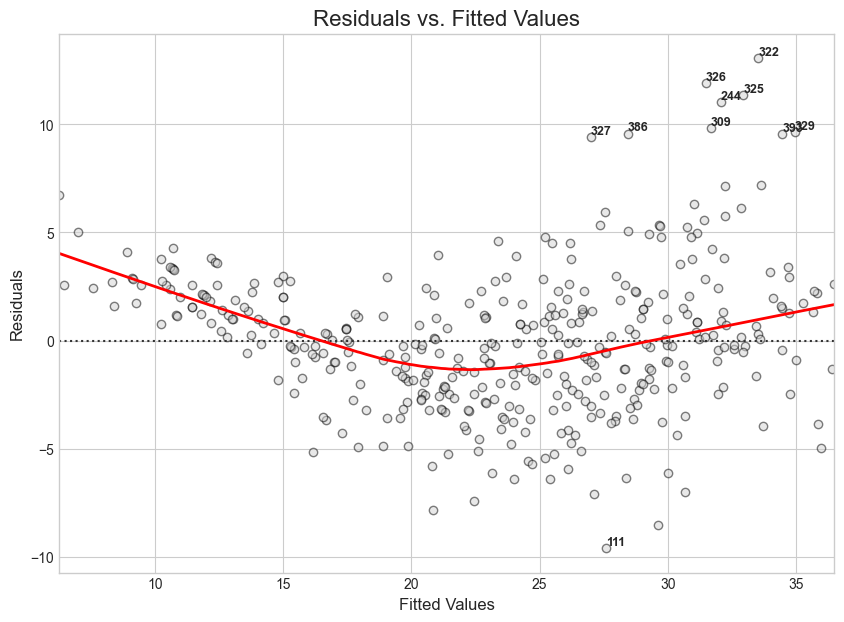

```python
# RESIDUALS PLOT REFERENCE LINK: https://seaborn.pydata.org/generated/seaborn.residplot.html

residuals = model.resid
fitted_values = model.fittedvalues

# Set up the plot
plt.style.use('seaborn-v0_8-whitegrid')
fig, ax = plt.subplots(figsize=(10, 7))

# Use seaborn.residplot which creates the scatter plot and adds a LOWESS smoother
sns.residplot(
    x=fitted_values,
    y=residuals,
    lowess=True,  # This adds the LOWESS trend line
    ax=ax,
    scatter_kws={'alpha': 0.5, 'facecolors': 'lightgray', 'edgecolors': 'k'},
    line_kws={'color': 'red', 'lw': 2}
)

#Identify the outlying points, reference found here: https://stackoverflow.com/questions/6910641/how-do-i-get-indices-of-n-maximum-values-in-a-numpy-array
abs_residuals = np.absolute(residuals)
top_n = 10
top_indices = abs_residuals.nlargest(top_n).index

# Add text labels for these points
for i in top_indices:
    ax.text(fitted_values[i], residuals[i], str(i),
            horizontalalignment='left',
            verticalalignment='bottom',
            fontsize=9,
            fontweight='bold')

# Set titles and labels for clarity
ax.set_title('Residuals vs. Fitted Values', fontsize=16)
ax.set_xlabel('Fitted Values', fontsize=12)
ax.set_ylabel('Residuals', fontsize=12)

plt.show()
```

**This plot exhibits heteroscedasticity, which can be corrected with a log transform. Let's do that.**

```python
y_log = np.log(auto['mpg'])
predictors = quantitative.drop('mpg')
log_corrected_auto = auto.copy()
for pred in predictors:
    log_corrected_auto[pred] = np.log(log_corrected_auto[pred])
x_log = sm.add_constant(log_corrected_auto[predictors])
model_log = sm.OLS(y_log, x_log, data=log_corrected_auto).fit()
print(model_log.summary())
```

```
                            OLS Regression Results
==============================================================================
Dep. Variable:                    mpg   R-squared:                       0.890
Model:                            OLS   Adj. R-squared:                  0.888
Method:                 Least Squares   F-statistic:                     445.3
Date:                Fri, 18 Jul 2025   Prob (F-statistic):          5.86e-180
Time:                        17:06:05   Log-Likelihood:                 300.34
No. Observations:                 392   AIC:                            -584.7
Df Residuals:                     384   BIC:                            -552.9
Df Model:                           7
Covariance Type:            nonrobust
================================================================================
                   coef    std err          t      P>|t|      [0.025      0.975]
--------------------------------------------------------------------------------
const           -0.1554      0.648     -0.240      0.811      -1.430       1.119
cylinders       -0.0828      0.061     -1.348      0.178      -0.204       0.038
displacement     0.0066      0.057      0.116      0.907      -0.105       0.119
horsepower      -0.2944      0.058     -5.106      0.000      -0.408      -0.181
weight          -0.5697      0.082     -6.914      0.000      -0.732      -0.408
acceleration    -0.1792      0.060     -3.011      0.003      -0.296      -0.062
year             2.2440      0.132     17.044      0.000       1.985       2.503
origin           0.0448      0.019      2.383      0.018       0.008       0.082
==============================================================================
Omnibus:                        8.794   Durbin-Watson:                   1.501
Prob(Omnibus):                  0.012   Jarque-Bera (JB):               14.713
Skew:                          -0.059   Prob(JB):                     0.000638
Kurtosis:                       3.942   Cond. No.                     1.36e+03
==============================================================================

Notes:
[1] Standard Errors assume that the covariance matrix of the errors is correctly specified.
[2] The condition number is large, 1.36e+03. This might indicate that there are
strong multicollinearity or other numerical problems.
```

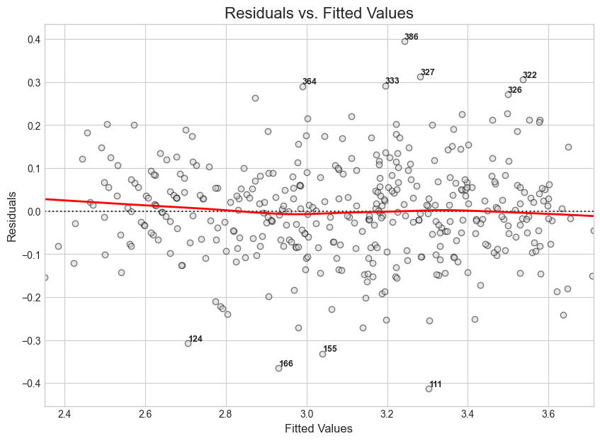

```python
# RESIDUALS PLOT REFERENCE LINK: https://seaborn.pydata.org/generated/seaborn.residplot.html

residuals_log = model_log.resid
fitted_values_log = model_log.fittedvalues

# Set up the plot
plt.style.use('seaborn-v0_8-whitegrid')
fig, ax = plt.subplots(figsize=(10, 7))

# Use seaborn.residplot which creates the scatter plot and adds a LOWESS smoother
sns.residplot(
    x=fitted_values_log,
    y=residuals_log,
    lowess=True,  # This adds the LOWESS trend line
    ax=ax,
    scatter_kws={'alpha': 0.5, 'facecolors': 'lightgray', 'edgecolors': 'k'},
    line_kws={'color': 'red', 'lw': 2}
)

#Identify the outlying points, reference found here: https://stackoverflow.com/questions/6910641/how-do-i-get-indices-of-n-maximum-values-in-a-numpy-array
abs_residuals_log = np.absolute(residuals_log)
top_n = 10
top_indices = abs_residuals_log.nlargest(top_n).index

# Add text labels for these points
for i in top_indices:
    ax.text(fitted_values_log[i], residuals_log[i], str(i),
            horizontalalignment='left',
            verticalalignment='bottom',
            fontsize=9,
            fontweight='bold')

# Set titles and labels for clarity
ax.set_title('Residuals vs. Fitted Values', fontsize=16)
ax.set_xlabel('Fitted Values', fontsize=12)
ax.set_ylabel('Residuals', fontsize=12)

plt.show()
```

**Great, the heteroscedasticity has been corrected. The outliers seem to have changed, but this makes sense given the non-linear effect of the log transform. Data points 326 and 327 were consistently outliers in both normal and log transformed residual plots. The key outcome of the residual plots is that the model is not properly catpuring some non-linear relationships in the data, which, looking back at the scatter matrix, is expected. Weight, Horsepower, Displacement, and Acceleration are all non-linearly related to mpg, so they are likely contributing to the effect seen in the residuals plots.**

**Now, let's look at the leverage plot.**

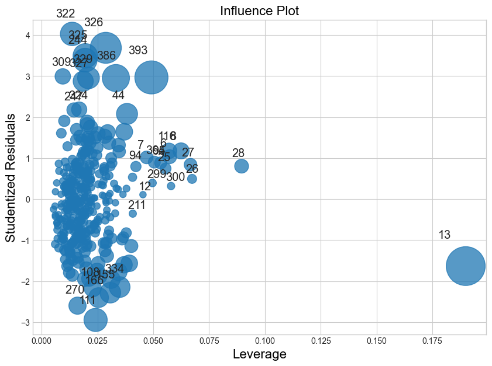

```python
fig, ax = plt.subplots(figsize=(10, 7))
fig = sm.graphics.influence_plot(model, ax=ax, criterion="cooks")
```

**Based on this leverage plot, which utilizes Cook's for bubble scaling, data point 13 is the most influencial in the dataset. Interestingly, this point is not an outlier. It is an unusual point, but fits the model's trend well. All of the outliers identified in the residuals plots exhibit high Cook's distances, which I would expect because outliers have a disproportionate influence on the model. However, their leverage is low, implying that the model does not predict these values well, therefore they are true outliers.**

## Part E

Fit some models with interactions as described in the lab. Do any interactions appear to be statistically significant?

```python
import statsmodels.formula.api as smf
```

**I am interested in the following interactions of predictors on mpg:**

1. **Year and Weight**
2. **Year and Origin**
3. **Acceleration and Displacement**
4. **Horsepower and Weight**

```python
year_weight_model = smf.ols('mpg ~ year * weight', data=auto).fit()
year_origin_model = smf.ols('mpg ~ year * origin', data=auto).fit()
accel_disp_model = smf.ols('mpg ~ acceleration * displacement', data=auto).fit()
hp_weight_model = smf.ols('mpg ~ horsepower * weight', data=auto).fit()
```

```python
# Source found here: https://stackoverflow.com/questions/51734180/converting-statsmodels-summary-object-to-pandas-dataframe
year_weight_model_results = pd.read_html(year_weight_model.summary().tables[1].as_html(), header=0, index_col=0)[0]
print(f'R-Squared: {round(year_weight_model.rsquared, 3)}')
print(year_weight_model_results)
```

```
R-Squared: 0.834
                 coef    std err       t  P>|t|   [0.025  0.975]
Intercept   -110.4519  12.947000  -8.531    0.0 -135.907 -84.997
year           2.0405   0.172000  11.876    0.0    1.703   2.378
weight         0.0275   0.004000   6.242    0.0    0.019   0.036
year:weight   -0.0005   0.000059  -7.752    0.0   -0.001  -0.000
```

```python
year_origin_model_results = pd.read_html(year_origin_model.summary().tables[1].as_html(), header=0, index_col=0)[0]
print(f'R-Squared: {round(year_origin_model.rsquared, 3)}')
print(year_origin_model_results)
```

```
R-Squared: 0.56
                coef  std err      t  P>|t|   [0.025  0.975]
Intercept   -83.3809   12.000 -6.948  0.000 -106.974 -59.788
year          1.3089    0.158  8.305  0.000    0.999   1.619
origin       17.3752    6.833  2.543  0.011    3.942  30.809
year:origin  -0.1663    0.089 -1.871  0.062   -0.341   0.008
```

```python
accel_disp_model_results = pd.read_html(accel_disp_model.summary().tables[1].as_html(), header=0, index_col=0)[0]
print(f'R-Squared: {round(accel_disp_model.rsquared, 3)}')
print(accel_disp_model_results)
```

```
R-Squared: 0.677
                              coef  std err      t  P>|t|  [0.025  0.975]
Intercept                  23.0533    2.922  7.889  0.000  17.308  28.798
acceleration                0.8303    0.182  4.574  0.000   0.473   1.187
displacement                0.0031    0.011  0.277  0.782  -0.019   0.025
acceleration:displacement  -0.0046    0.001 -5.799  0.000  -0.006  -0.003
```

```python
hp_weight_model_results = pd.read_html(hp_weight_model.summary().tables[1].as_html(), header=0, index_col=0)[0]
print(f'R-Squared: {round(hp_weight_model.rsquared, 3)}')
print(hp_weight_model_results)
```

```
R-Squared: 0.748
                        coef   std err       t  P>|t|     [0.025     0.975]
Intercept          63.557900  2.343000  27.127    0.0  58.951000  68.164000
horsepower         -0.250800  0.027000  -9.195    0.0  -0.304000  -0.197000
weight             -0.010800  0.001000 -13.921    0.0  -0.012000  -0.009000
horsepower:weight   0.000054  0.000007   8.054    0.0   0.000041   0.000067
```

**After analyzing each of the interactions, I have concluded the following interactions are statistically significant when predicting mpg:**

1. **Year:Weight**
2. **Acceleration:Displacement**
3. **Horsepower:Weight**

**Each of these interactions have a p-value of less than 0.05, indicating that they are statistically significant.**

**Just out of curiosity, I'd like to look at the residual plots for these models. I suspect some of the relationships will be quite linear.**

```python
def plot_residuals(model, ax, title, x_label, y_label, outlier_count = 10):
    # RESIDUALS PLOT REFERENCE LINK: https://seaborn.pydata.org/generated/seaborn.residplot.html
    residuals = model.resid
    fitted_values = model.fittedvalues

    # Use seaborn.residplot which creates the scatter plot and adds a LOWESS smoother
    sns.residplot(
        x=fitted_values,
        y=residuals,
        lowess=True,  # This adds the LOWESS trend line
        ax=ax,
        scatter_kws={'alpha': 0.5, 'facecolors': 'lightgray', 'edgecolors': 'k'},
        line_kws={'color': 'red', 'lw': 2}
    )

    #Identify the outlying points, reference found here: https://stackoverflow.com/questions/6910641/how-do-i-get-indices-of-n-maximum-values-in-a-numpy-array
    abs_residuals = np.absolute(residuals)
    top_n = outlier_count
    top_indices = abs_residuals.nlargest(top_n).index

    # Add text labels for these points
    for i in top_indices:
        ax.text(fitted_values[i], residuals[i], str(i),
                horizontalalignment='left',
                verticalalignment='bottom',
                fontsize=9,
                fontweight='bold')

    # Set titles and labels for clarity
    ax.set_title(title, fontsize=16)
    ax.set_xlabel(x_label, fontsize=12)
    ax.set_ylabel(y_label, fontsize=12)
```

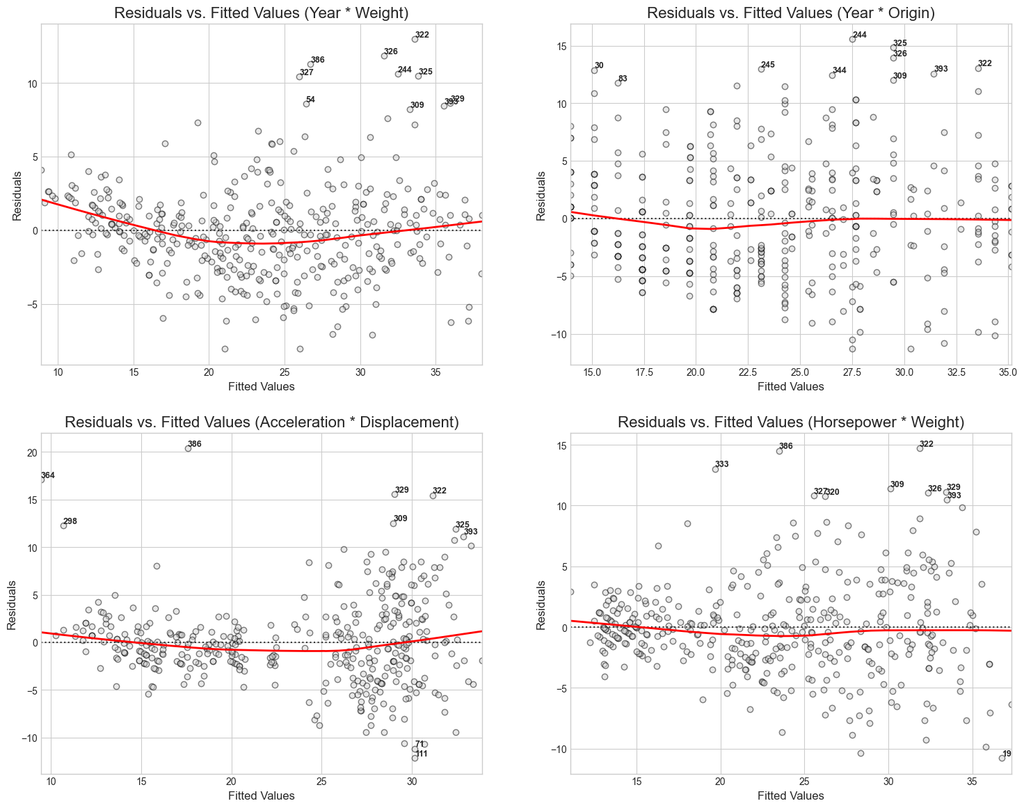

```python
fig, axes = plt.subplots(2, 2, figsize=(18,14));

title='Residuals vs. Fitted Values'
x_label='Fitted Values'
y_label='Residuals'

plot_residuals(year_weight_model, axes[0,0], title=f'{title} (Year * Weight)', x_label=x_label, y_label=y_label);
plot_residuals(year_origin_model, axes[0,1], title=f'{title} (Year * Origin)', x_label=x_label, y_label=y_label);
plot_residuals(accel_disp_model, axes[1,0], title=f'{title} (Acceleration * Displacement)', x_label=x_label, y_label=y_label);
plot_residuals(hp_weight_model, axes[1,1], title=f'{title} (Horsepower * Weight)', x_label=x_label, y_label=y_label);

plt.show()
```

## Part F

Try a few different transformations of the variables, such as log(X), √X, X2. Comment on your findings.

**The log transformed model was completed in a previous part. Let's do the other transforms.**

```python
y_sqrt = np.sqrt(auto['mpg'])
sqrt_transformed_auto = auto.copy()

for pred in predictors:
    sqrt_transformed_auto[pred] = np.sqrt(sqrt_transformed_auto[pred])

x_sqrt = sm.add_constant(sqrt_transformed_auto[predictors])
model_sqrt = sm.OLS(y_sqrt, x_sqrt, data=sqrt_transformed_auto).fit()
```

```python
y_square = np.square(auto['mpg'])
square_transformed_auto = auto.copy()

for pred in predictors:
    square_transformed_auto[pred] = np.square(square_transformed_auto[pred])

x_square = sm.add_constant(square_transformed_auto[predictors])
model_square = sm.OLS(y_square, x_square, data=square_transformed_auto).fit()
```

```python
model_log_results = pd.read_html(model_log.summary().tables[1].as_html(), header=0, index_col=0)[0]
print(f'R-Squared: {round(model_log.rsquared, 3)}')
print(model_log_results)
```

```
R-Squared: 0.89
                coef  std err       t  P>|t|  [0.025  0.975]
const        -0.1554    0.648  -0.240  0.811  -1.430   1.119
cylinders    -0.0828    0.061  -1.348  0.178  -0.204   0.038
displacement  0.0066    0.057   0.116  0.907  -0.105   0.119
horsepower   -0.2944    0.058  -5.106  0.000  -0.408  -0.181
weight       -0.5697    0.082  -6.914  0.000  -0.732  -0.408
acceleration -0.1792    0.060  -3.011  0.003  -0.296  -0.062
year          2.2440    0.132  17.044  0.000   1.985   2.503
origin        0.0448    0.019   2.383  0.018   0.008   0.082
```

```python
model_sqrt_results = pd.read_html(model_sqrt.summary().tables[1].as_html(), header=0, index_col=0)[0]
print(f'R-Squared: {round(model_sqrt.rsquared, 3)}')
print(model_sqrt_results)
```

```
R-Squared: 0.866
                coef  std err       t  P>|t|  [0.025  0.975]
const        -1.9493    0.847  -2.300  0.022  -3.616  -0.283
cylinders    -0.1086    0.142  -0.765  0.445  -0.388   0.171
displacement  0.0197    0.021   0.930  0.353  -0.022   0.061
horsepower   -0.0909    0.028  -3.197  0.002  -0.147  -0.035
weight       -0.0614    0.007  -8.422  0.000  -0.076  -0.047
acceleration -0.1073    0.077  -1.392  0.165  -0.259   0.044
year          1.2660    0.079  15.963  0.000   1.110   1.422
origin        0.2723    0.071   3.842  0.000   0.133   0.412
```

```python
model_square_results = pd.read_html(model_square.summary().tables[1].as_html(), header=0, index_col=0)[0]
print(f'R-Squared: {round(model_square.rsquared, 3)}')
print(model_square_results)
```

```
R-Squared: 0.706
                    coef     std err       t  P>|t|       [0.025      0.975]
const        -752.288000  145.649000  -5.165  0.000 -1038.658000 -465.918000
cylinders      -3.746000    1.559000  -2.403  0.017    -6.810000   -0.682000
displacement    0.003400    0.001000   3.926  0.000     0.002000    0.005000
horsepower      0.000100    0.003000   0.042  0.967    -0.006000    0.006000
weight         -0.000048    0.000006  -8.707  0.000    -0.000059   -0.000037
acceleration    0.489200    0.166000   2.941  0.003     0.162000    0.816000
year            0.273100    0.022000  12.513  0.000     0.230000    0.316000
origin         26.083900    4.275000   6.101  0.000    17.678000   34.489000
```

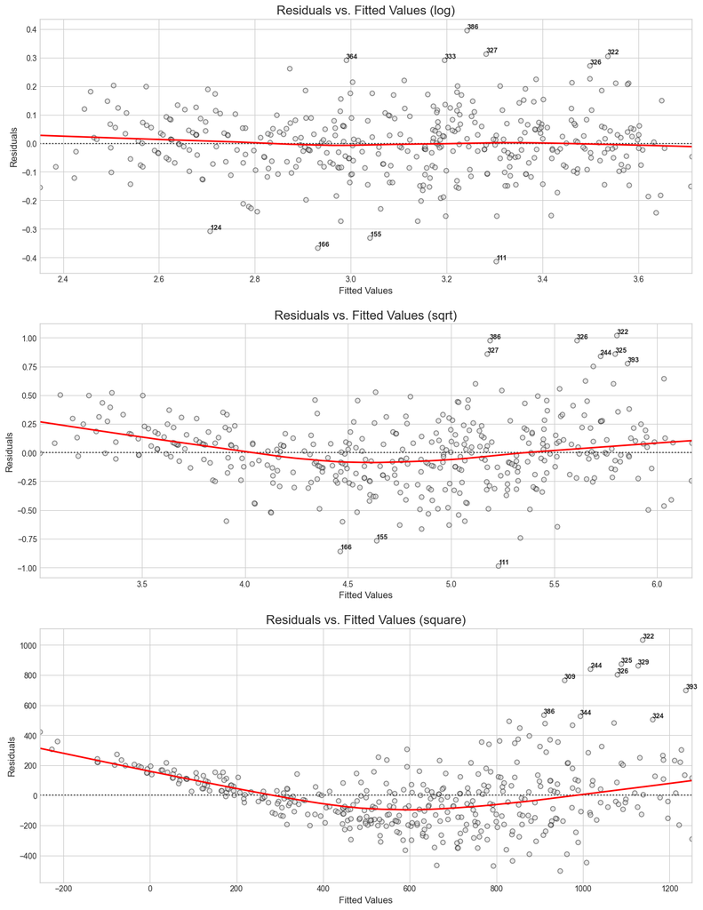

```python
fig, axes = plt.subplots(3,1, figsize=(15,20));

title='Residuals vs. Fitted Values'
x_label='Fitted Values'
y_label='Residuals'

plot_residuals(model_log, axes[0], title=f'{title} (log)', x_label=x_label, y_label=y_label);
plot_residuals(model_sqrt, axes[1], title=f'{title} (sqrt)', x_label=x_label, y_label=y_label);
plot_residuals(model_square, axes[2], title=f'{title} (square)', x_label=x_label, y_label=y_label);


plt.show()
```

**These transforms to the data impacted the models as expected. The log transform 'linearized' the data, resulting in a higher R<sup>2</sup> value and more statistically significant predictors. The square root transform worked to remove some of the non-linearity from the data, however, it is clear that there are some polynomial relationships that could not be corrected with a square-root transformation. This is evident from the non-linear residual plot. Lastly, the square transform produced the worst R<sup>2</sup> value, which was expected. This transform would exacerbate any interactions and non-linear behavior, and OLS is a linear model. Interestingly, in the square transform model, acceleration and cylinders became statistically significant predictors of mpg.**

# Problem 10

This question should be answered using the Carseats data set.

Carseats is simulated data set containing sales of child car seats at 400 different stores.

```python
from ISLP import load_data

carseats = load_data('carseats')
carseats.head(5)
```

|  | Sales | CompPrice | Income | Advertising | Population | Price | ShelveLoc | Age | Education | Urban | US |
| --- | --- | --- | --- | --- | --- | --- | --- | --- | --- | --- | --- |
| 0 | 9.50 | 138 | 73 | 11 | 276 | 120 | Bad | 42 | 17 | Yes | Yes |
| 1 | 11.22 | 111 | 48 | 16 | 260 | 83 | Good | 65 | 10 | Yes | Yes |
| 2 | 10.06 | 113 | 35 | 10 | 269 | 80 | Medium | 59 | 12 | Yes | Yes |
| 3 | 7.40 | 117 | 100 | 4 | 466 | 97 | Medium | 55 | 14 | Yes | Yes |
| 4 | 4.15 | 141 | 64 | 3 | 340 | 128 | Bad | 38 | 13 | Yes | No |

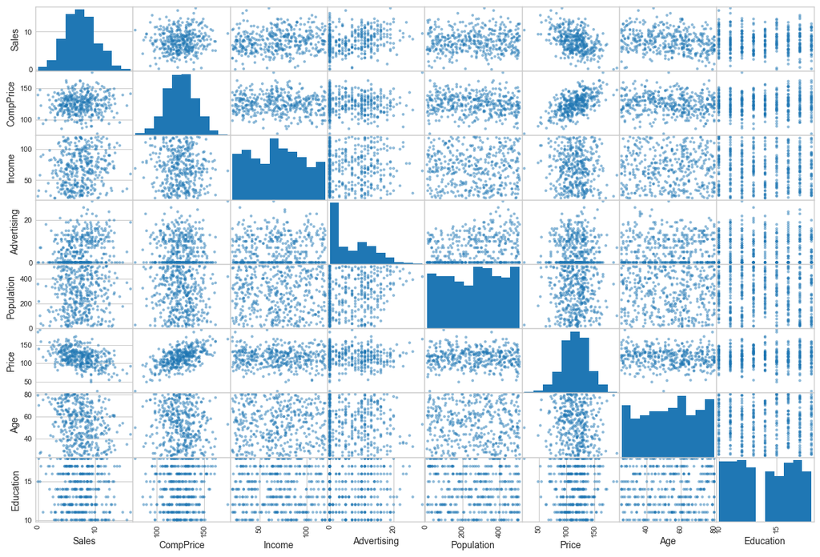

```python
pd.plotting.scatter_matrix(carseats, figsize=(15,10));
```

## Part A

Fit a multiple regression model to predict Sales using Price, Urban, and US.

**Urban and US are qualitative measures. To address this for the linear model, I am going to remap their values to 0 (No) and 1 (Yes).**

```python
carseats_remapped = carseats.copy()
carseats_remapped['Urban'].replace({'Yes':1, 'No':0}, inplace=True)
carseats_remapped['US'].replace({'Yes':1, 'No':0}, inplace=True)
carseats_remapped.head(5)
```

|  | Sales | CompPrice | Income | Advertising | Population | Price | ShelveLoc | Age | Education | Urban | US |
| --- | --- | --- | --- | --- | --- | --- | --- | --- | --- | --- | --- |
| 0 | 9.50 | 138 | 73 | 11 | 276 | 120 | Bad | 42 | 17 | 1 | 1 |
| 1 | 11.22 | 111 | 48 | 16 | 260 | 83 | Good | 65 | 10 | 1 | 1 |
| 2 | 10.06 | 113 | 35 | 10 | 269 | 80 | Medium | 59 | 12 | 1 | 1 |
| 3 | 7.40 | 117 | 100 | 4 | 466 | 97 | Medium | 55 | 14 | 1 | 1 |
| 4 | 4.15 | 141 | 64 | 3 | 340 | 128 | Bad | 38 | 13 | 1 | 0 |

```python
y_carseat = carseats_remapped['Sales']
predictors = ['Price', 'Urban', 'US']
x_carseat = sm.add_constant(carseats_remapped[predictors])
carseat_remapped_model = sm.OLS(y_carseat,x_carseat,data=carseats_remapped).fit()
print(carseat_remapped_model.summary())
```

```
                            OLS Regression Results
==============================================================================
Dep. Variable:                  Sales   R-squared:                       0.239
Model:                            OLS   Adj. R-squared:                  0.234
Method:                 Least Squares   F-statistic:                     41.52
Date:                Fri, 18 Jul 2025   Prob (F-statistic):           2.39e-23
Time:                        17:06:09   Log-Likelihood:                -927.66
No. Observations:                 400   AIC:                             1863.
Df Residuals:                     396   BIC:                             1879.
Df Model:                           3
Covariance Type:            nonrobust
==============================================================================
                 coef    std err          t      P>|t|      [0.025      0.975]
------------------------------------------------------------------------------
const         13.0435      0.651     20.036      0.000      11.764      14.323
Price         -0.0545      0.005    -10.389      0.000      -0.065      -0.044
Urban         -0.0219      0.272     -0.081      0.936      -0.556       0.512
US             1.2006      0.259      4.635      0.000       0.691       1.710
==============================================================================
Omnibus:                        0.676   Durbin-Watson:                   1.912
Prob(Omnibus):                  0.713   Jarque-Bera (JB):                0.758
Skew:                           0.093   Prob(JB):                        0.684
Kurtosis:                       2.897   Cond. No.                         628.
==============================================================================

Notes:
[1] Standard Errors assume that the covariance matrix of the errors is correctly specified.
```

**Now, I want to do the same thing leaving the qualitative measures untouched. I suspect there will be a difference in the model summary.**

```python
carseat_model = smf.ols('Sales ~ Price + Urban + US', data=carseats).fit()
print(carseat_model.summary())
```

```
                            OLS Regression Results
==============================================================================
Dep. Variable:                  Sales   R-squared:                       0.239
Model:                            OLS   Adj. R-squared:                  0.234
Method:                 Least Squares   F-statistic:                     41.52
Date:                Fri, 18 Jul 2025   Prob (F-statistic):           2.39e-23
Time:                        17:06:09   Log-Likelihood:                -927.66
No. Observations:                 400   AIC:                             1863.
Df Residuals:                     396   BIC:                             1879.
Df Model:                           3
Covariance Type:            nonrobust
================================================================================
                   coef    std err          t      P>|t|      [0.025      0.975]
--------------------------------------------------------------------------------
Intercept       13.0435      0.651     20.036      0.000      11.764      14.323
Urban[T.Yes]    -0.0219      0.272     -0.081      0.936      -0.556       0.512
US[T.Yes]        1.2006      0.259      4.635      0.000       0.691       1.710
Price           -0.0545      0.005    -10.389      0.000      -0.065      -0.044
==============================================================================
Omnibus:                        0.676   Durbin-Watson:                   1.912
Prob(Omnibus):                  0.713   Jarque-Bera (JB):                0.758
Skew:                           0.093   Prob(JB):                        0.684
Kurtosis:                       2.897   Cond. No.                         628.
==============================================================================

Notes:
[1] Standard Errors assume that the covariance matrix of the errors is correctly specified.
```

**Okay, so the coefficient output is the same. The second OLS model must automatically remap qualitative variables... Interesting.**

## Part B

Provide an interpretation of each coefficient in the model. Be careful—some of the variables in the model are qualitative!

1. Urban
   - Holding price and US location constant, an urban store is predicted to have sales that are, on average, 0.0219 units lower than a non-urban store. The coefficient is a per unit measure relative to Sales, therefore the average difference between urban and non-urban sales is 0.0219 per unit.
2. US
   - Similar to Urban, a coefficient of 1.2006 indicates a unit increase of 1.2006 Sales for a 'Yes' value in the US dataset, relative to a baseline of 'No.'
3. Price
   - A price coefficient of -0.0545 indicates that a unit price change results in 0.0545 fewer sales.

## Part C

Write out the model in equation form, being careful to handle the qualitative variables properly.

**Base MLR Formula:**

y = β₀ + β₁x₁ + β₂x₂ + ... + β<sub>k</sub>x<sub>k</sub> + ε

**The Urban and US variables were evaluated as binary values of 1 or 0, the equation can be modeled as seen, below:**

Y = 13.0435 - (0.0219 * Urban[Yes]) + (1.2006 * US[Yes]) - 0.0545 * Price + ε

→ Y = 13.0435 - (0.0219 * 1) + (1.2006 * 1) - 0.0545 * Price + ε

**This model is generally true for both Yes and No cases in Urban and US because the terms drop out when they are evaluated as No, resulting in the equation, below:**

Y = 13.0435 - (0.0219 * Urban[No]) + (1.2006 * US[No]) - 0.0545 * Price + ε

→ Y = 13.0435 - (0.0219 * 0) + (1.2006 * 0) - 0.0545 * Price + ε

→ Y = 13.0435 - 0.0545 * Price + ε

**NOTE: This is also true for any combination of Yes and No for Urban or US. The terms will always drop out if they are No.**

## Part D

For which of the predictors can you reject the null hypothesis H0:βj = 0?

**The p-value associated with the t-statistic can be used to determine which predictors are statistically significant (i.e. the null hypothesis is rejected). Based on a significance level of 0.05, US[T.Yes] and Price are statistically significant because their p-values are 0.**

## Part E

On the basis of your response to the previous question, fit a smaller model that only uses the predictors for which there is evidence of association with the outcome.

```python
smaller_carseat_model = smf.ols('Sales ~ Price + US', data=carseats).fit()
print(smaller_carseat_model.summary())
```

```
                            OLS Regression Results
==============================================================================
Dep. Variable:                  Sales   R-squared:                       0.239
Model:                            OLS   Adj. R-squared:                  0.235
Method:                 Least Squares   F-statistic:                     62.43
Date:                Fri, 18 Jul 2025   Prob (F-statistic):           2.66e-24
Time:                        17:06:09   Log-Likelihood:                -927.66
No. Observations:                 400   AIC:                             1861.
Df Residuals:                     397   BIC:                             1873.
Df Model:                           2
Covariance Type:            nonrobust
==============================================================================
                 coef    std err          t      P>|t|      [0.025      0.975]
------------------------------------------------------------------------------
Intercept     13.0308      0.631     20.652      0.000      11.790      14.271
US[T.Yes]      1.1996      0.258      4.641      0.000       0.692       1.708
Price         -0.0545      0.005    -10.416      0.000      -0.065      -0.044
==============================================================================
Omnibus:                        0.666   Durbin-Watson:                   1.912
Prob(Omnibus):                  0.717   Jarque-Bera (JB):                0.749
Skew:                           0.092   Prob(JB):                        0.688
Kurtosis:                       2.895   Cond. No.                         607.
==============================================================================

Notes:
[1] Standard Errors assume that the covariance matrix of the errors is correctly specified.
```

## Part F

How well do the models in (a) and (e) fit the data?

**Both models have an R<sup>2</sup> value of 0.239, suggesting they equally fit he model. An R<sup>2</sup> value of 0.239 indicates that the model only explains 23.9% of the variance in the data, which is poor. The models do not fit the data well.**

## Part G

Using the model from (e), obtain 95% confidence intervals for the coefficient(s).

```python
smaller_carseat_model.conf_int(alpha=0.05)
```

|  | 0 | 1 |
| --- | --- | --- |
| Intercept | 11.79032 | 14.271265 |
| US[T.Yes] | 0.69152 | 1.707766 |
| Price | -0.06476 | -0.044195 |

## Part H

Is there evidence of outliers or high leverage observations in the model from (e)?

[figure not shown]

```python
fig, axes = plt.subplots(1,1, figsize=(10,10));

title='Residuals vs. Fitted Values'
x_label='Fitted Values'
y_label='Residuals'

plot_residuals(smaller_carseat_model, axes, title=f'{title} (log)', x_label=x_label, y_label=y_label, outlier_count = 3);
```

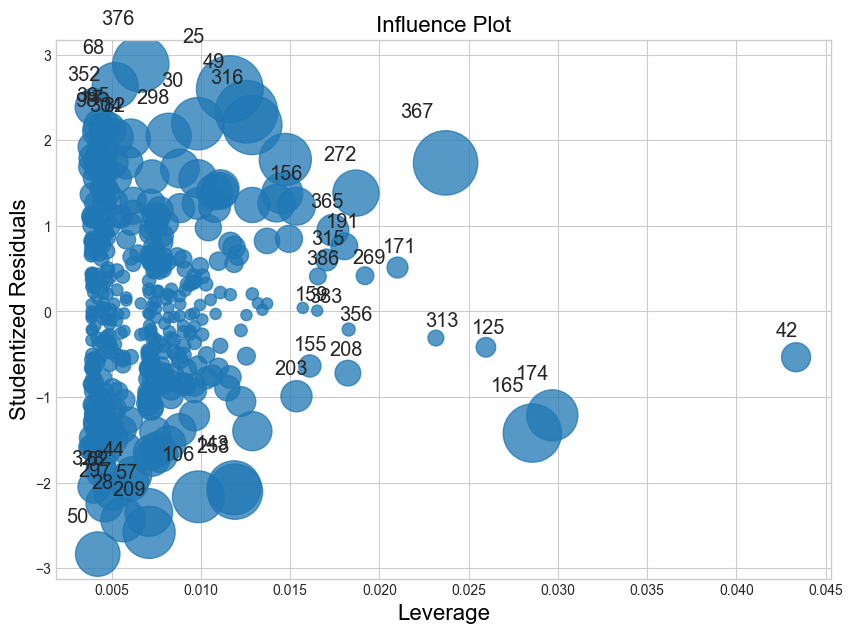

```python
fig, ax = plt.subplots(figsize=(10, 7))
fig = sm.graphics.influence_plot(smaller_carseat_model, ax=ax, criterion="cooks")
```

**Observation 42 is a high leverage data point, and observations 50, 68, and 376 are outliers. Each of the outliers have a leverage less than ~0.0075, which, on top of these observations being outliers in the residuals plot, is a clear indication that they are truly outliers and do not have influence on the model.**

# Problem 14

This problem focuses on the collinearity problem.

## Part A

Perform the following commands in Python:

```
rng = np.random.default_rng(10)
x1 = rng.uniform(0, 1, size=100)
x2 = 0.5 * x1 + rng.normal(size=100) / 10
y = 2 + 2 * x1 + 0.3 * x2 + rng.normal(size=100)
```

The last line corresponds to creating a linear model in which y is a function of x1 and x2. Write out the form of the linear model. What are the regression coefficients?

```python
rng = np.random.default_rng(10)
x1 = rng.uniform(0, 1, size=100)
x2 = 0.5 * x1 + rng.normal(size=100) / 10
y = 2 + 2 * x1 + 0.3 * x2 + rng.normal(size=100)
```

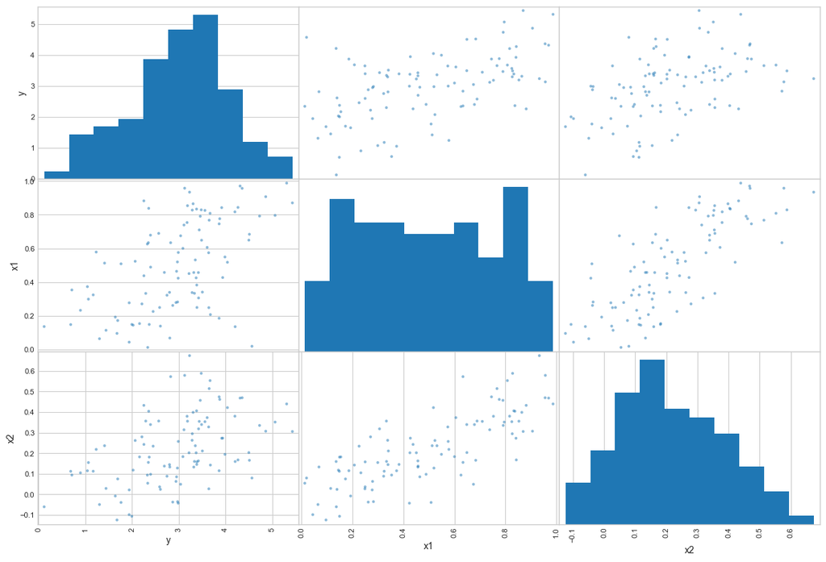

```python
df = pd.DataFrame({'y':list(y), 'x1':list(x1), 'x2':list(x2)})
pd.plotting.scatter_matrix(df, figsize=(15,10));
```

**From the linear model equation, below, the form of the linear model can be determined.**

y = β₀ + β₁x₁ + β₂x₂ + ... + β<sub>k</sub>x<sub>k</sub> + ε

**Where:**

**β₀** is the intercept (2),

**β₁** is the regression coefficient of x1 (2),

**β₂** is the regression coefficient of x2 (0.3),

**ε** is the error (a randomly generated, normally distributed array of 100 observations, in this case.)

## Part B

What is the correlation between x1 and x2? Create a scatterplot displaying the relationship between the variables.

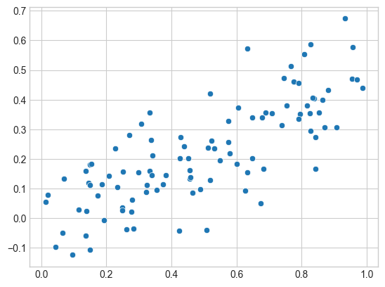

```python
sns.scatterplot(x=x1, y=x2)
```

```python
np.corrcoef(x1, x2)
```

```
array([[1.       , 0.7723245],
       [0.7723245, 1.       ]])
```

**There is a linear relationship between these two variables, with a correlation coefficient of 0.772. A perfect correlation would have a coefficient of 1, therefore this is a strong linear correlation.**

## Part C

Using this data, fit a least squares regression to predict y using x1 and x2. Describe the results obtained. What are ˆβ0, ˆβ1, andˆβ2? How do these relate to the true β0, β1, and β2? Can you reject the null hypothesis H0 : β1 = 0 ? How about the null hypothesis H0 : β2 = 0 ?

```python
y = df['y']
predictors = ['x1', 'x2']
X = sm.add_constant(df[predictors])
ls_model = sm.OLS(endog=y, exog=X).fit()
print(ls_model.summary())
```

```
                            OLS Regression Results
==============================================================================
Dep. Variable:                      y   R-squared:                       0.291
Model:                            OLS   Adj. R-squared:                  0.276
Method:                 Least Squares   F-statistic:                     19.89
Date:                Fri, 18 Jul 2025   Prob (F-statistic):           5.76e-08
Time:                        17:06:10   Log-Likelihood:                -130.62
No. Observations:                 100   AIC:                             267.2
Df Residuals:                      97   BIC:                             275.1
Df Model:                           2
Covariance Type:            nonrobust
==============================================================================
                 coef    std err          t      P>|t|      [0.025      0.975]
------------------------------------------------------------------------------
const          1.9579      0.190     10.319      0.000       1.581       2.334
x1             1.6154      0.527      3.065      0.003       0.569       2.661
x2             0.9428      0.831      1.134      0.259      -0.707       2.592
==============================================================================
Omnibus:                        0.051   Durbin-Watson:                   1.964
Prob(Omnibus):                  0.975   Jarque-Bera (JB):                0.041
Skew:                          -0.036   Prob(JB):                        0.979
Kurtosis:                       2.931   Cond. No.                         11.9
==============================================================================

Notes:
[1] Standard Errors assume that the covariance matrix of the errors is correctly specified.
```

**The results of the model produced the following values:**

1. ˆβ0 = 1.9579
2. ˆβ1 = 1.6154
3. ˆβ2 = 0.9428

**The values of β0, β1, and β2 are 2, 2, and 0.3, respectively, which differ from ˆβ0, ˆβ1, and ˆβ2. Of the OLS predicted β values, β1 can be rejected (p-value < 0.05), however, β2 cannot be rejected (p-value > 0.05). This is expected, given the difference in the predicted β and the true β that were used to generate y against x1 and x2.**

## Part D

Now fit a least squares regression to predict y using only x1. Comment on your results. Can you reject the null hypothesis H0 : β1 = 0 ?

```python
y = df['y']
predictors = ['x1']
X = sm.add_constant(df[predictors])
ls_model2 = sm.OLS(endog=y, exog=X).fit()
print(ls_model2.summary())
```

```
                            OLS Regression Results
==============================================================================
Dep. Variable:                      y   R-squared:                       0.281
Model:                            OLS   Adj. R-squared:                  0.274
Method:                 Least Squares   F-statistic:                     38.39
Date:                Fri, 18 Jul 2025   Prob (F-statistic):           1.37e-08
Time:                        17:06:10   Log-Likelihood:                -131.28
No. Observations:                 100   AIC:                             266.6
Df Residuals:                      98   BIC:                             271.8
Df Model:                           1
Covariance Type:            nonrobust
==============================================================================
                 coef    std err          t      P>|t|      [0.025      0.975]
------------------------------------------------------------------------------
const          1.9371      0.189     10.242      0.000       1.562       2.312
x1             2.0771      0.335      6.196      0.000       1.412       2.742
==============================================================================
Omnibus:                        0.204   Durbin-Watson:                   1.931
Prob(Omnibus):                  0.903   Jarque-Bera (JB):                0.042
Skew:                          -0.046   Prob(JB):                        0.979
Kurtosis:                       3.038   Cond. No.                         4.65
==============================================================================

Notes:
[1] Standard Errors assume that the covariance matrix of the errors is correctly specified.
```

**The reduction in R<sup>2</sup> indicates that this model predicts 1% less of the variance in the data, as compared to the model in Part C. The p-value for ˆβ1, however, has decreased to 0, and ˆβ1 (2.0771) is now nearly identical to the true coefficient of 2. The null hypothesis can be rejected.**

## Part E

Now fit a least squares regression to predict y using only x2. Comment on your results. Can you reject the null hypothesis H0 : β1 = 0 ?

```python
y = df['y']
predictors = ['x2']
X = sm.add_constant(df[predictors])
ls_model3 = sm.OLS(endog=y, exog=X).fit()
print(ls_model3.summary())
```

```
                            OLS Regression Results
==============================================================================
Dep. Variable:                      y   R-squared:                       0.222
Model:                            OLS   Adj. R-squared:                  0.214
Method:                 Least Squares   F-statistic:                     27.99
Date:                Fri, 18 Jul 2025   Prob (F-statistic):           7.43e-07
Time:                        17:06:10   Log-Likelihood:                -135.24
No. Observations:                 100   AIC:                             274.5
Df Residuals:                      98   BIC:                             279.7
Df Model:                           1
Covariance Type:            nonrobust
==============================================================================
                 coef    std err          t      P>|t|      [0.025      0.975]
------------------------------------------------------------------------------
const          2.3239      0.154     15.124      0.000       2.019       2.629
x2             2.9103      0.550      5.291      0.000       1.819       4.002
==============================================================================
Omnibus:                        0.191   Durbin-Watson:                   1.943
Prob(Omnibus):                  0.909   Jarque-Bera (JB):                0.373
Skew:                          -0.034   Prob(JB):                        0.830
Kurtosis:                       2.709   Cond. No.                         6.11
==============================================================================

Notes:
[1] Standard Errors assume that the covariance matrix of the errors is correctly specified.
```

**This OLS model now produces a β1 for the x2 variable that rejects the null hypothesis due to the p-value of 0. What this tells me is that there is an interaction between x1 and x2 that makes x2 a poor predictor of y when x1 is present. Referencing the scatter matrix at the beginning of this problem and the correlation coefficient in the cell, below, the coefficient of x2 in this model begins to make sense. Independently, x2 has a correlation coefficient of 0.47 with y. Ultimately, this model is a poor predictor of y, with an R<sup>2</sup> of 0.222.**

```python
np.corrcoef(y, x2)
```

```
array([[1.        , 0.47135592],
       [0.47135592, 1.        ]])
```

## Part F

Do the results obtained in (c)–(e) contradict each other? Explain your answer.

**There is a contradiction in parts c-e, where β2 in the original model does not reject the null hypothesis, but when x2 is modeled independently against y, β1 does reject the null hypothesis. As stated in my assessment during Part E, I suspect there is an interaction between x1 and x2. Digging deeper into this idea and referencing the original equation for x2, this hypothesis is supported. The x2 data is fundamentally a transformation of x1, which, when x1 is present, would be 'washed out' by the response between x1 and y. Additionally, the coefficients in the equation for y further amplify the input of x1 over x2, where x1 has a coefficient of 2 and x2 has a coefficient of 0.3. This effectively 'drowns out' the signal of x2 in y when x1 is present. When x2 predicts y without the influence of x1, it can do so reliably, because it is a derivative of x1, making the model a single predictor, single response equation.**

## Part G

Suppose we obtain one additional observation, which was unfortunately mismeasured. We use the function np.concatenate() to add this additional observation to each of x1, x2 and y.

```
x1 = np.concatenate([x1, [0.1]])
x2 = np.concatenate([x2, [0.8]])
y = np.concatenate([y, [6]])
```

Re-fit the linear models from (c) to (e) using this new data. What effect does this new observation have on the each of the models? In each model, is this observation an outlier? A high-leverage point? Both? Explain your answers.

```python
x1 = np.concatenate([x1, [0.1]])
x2 = np.concatenate([x2, [0.8]])
y = np.concatenate([y, [6]])

df = pd.DataFrame({'y':list(y), 'x1':list(x1), 'x2':list(x2)})
```

```python
#Model from part c
y = df['y']
predictors = ['x1', 'x2']
X = sm.add_constant(df[predictors])
ls_model = sm.OLS(endog=y, exog=X).fit()
print(ls_model.summary())
```

```
                            OLS Regression Results
==============================================================================
Dep. Variable:                      y   R-squared:                       0.292
Model:                            OLS   Adj. R-squared:                  0.277
Method:                 Least Squares   F-statistic:                     20.17
Date:                Fri, 18 Jul 2025   Prob (F-statistic):           4.60e-08
Time:                        17:06:11   Log-Likelihood:                -135.30
No. Observations:                 101   AIC:                             276.6
Df Residuals:                      98   BIC:                             284.5
Df Model:                           2
Covariance Type:            nonrobust
==============================================================================
                 coef    std err          t      P>|t|      [0.025      0.975]
------------------------------------------------------------------------------
const          2.0618      0.192     10.720      0.000       1.680       2.443
x1             0.8575      0.466      1.838      0.069      -0.068       1.783
x2             2.2663      0.705      3.216      0.002       0.868       3.665
==============================================================================
Omnibus:                        0.139   Durbin-Watson:                   1.894
Prob(Omnibus):                  0.933   Jarque-Bera (JB):                0.320
Skew:                           0.013   Prob(JB):                        0.852
Kurtosis:                       2.725   Cond. No.                         9.68
==============================================================================

Notes:
[1] Standard Errors assume that the covariance matrix of the errors is correctly specified.
```

```python
# Model from part D
y = df['y']
predictors = ['x1']
X = sm.add_constant(df[predictors])
ls_model2 = sm.OLS(endog=y, exog=X).fit()
print(ls_model2.summary())
```

```
                            OLS Regression Results
==============================================================================
Dep. Variable:                      y   R-squared:                       0.217
Model:                            OLS   Adj. R-squared:                  0.209
Method:                 Least Squares   F-statistic:                     27.42
Date:                Fri, 18 Jul 2025   Prob (F-statistic):           9.23e-07
Time:                        17:06:11   Log-Likelihood:                -140.37
No. Observations:                 101   AIC:                             284.7
Df Residuals:                      99   BIC:                             290.0
Df Model:                           1
Covariance Type:            nonrobust
==============================================================================
                 coef    std err          t      P>|t|      [0.025      0.975]
------------------------------------------------------------------------------
const          2.0739      0.201     10.310      0.000       1.675       2.473
x1             1.8760      0.358      5.236      0.000       1.165       2.587
==============================================================================
Omnibus:                        8.232   Durbin-Watson:                   1.636
Prob(Omnibus):                  0.016   Jarque-Bera (JB):               10.781
Skew:                           0.396   Prob(JB):                      0.00456
Kurtosis:                       4.391   Cond. No.                         4.61
==============================================================================

Notes:
[1] Standard Errors assume that the covariance matrix of the errors is correctly specified.
```

```python
# Model from part E
y = df['y']
predictors = ['x2']
X = sm.add_constant(df[predictors])
ls_model3 = sm.OLS(endog=y, exog=X).fit()
print(ls_model3.summary())
```

```
                            OLS Regression Results
==============================================================================
Dep. Variable:                      y   R-squared:                       0.267
Model:                            OLS   Adj. R-squared:                  0.260
Method:                 Least Squares   F-statistic:                     36.10
Date:                Fri, 18 Jul 2025   Prob (F-statistic):           3.13e-08
Time:                        17:06:11   Log-Likelihood:                -137.01
No. Observations:                 101   AIC:                             278.0
Df Residuals:                      99   BIC:                             283.3
Df Model:                           1
Covariance Type:            nonrobust
==============================================================================
                 coef    std err          t      P>|t|      [0.025      0.975]
------------------------------------------------------------------------------
const          2.2840      0.151     15.088      0.000       1.984       2.584
x2             3.1458      0.524      6.008      0.000       2.107       4.185
==============================================================================
Omnibus:                        0.495   Durbin-Watson:                   1.939
Prob(Omnibus):                  0.781   Jarque-Bera (JB):                0.631
Skew:                          -0.041   Prob(JB):                        0.729
Kurtosis:                       2.621   Cond. No.                         5.84
==============================================================================

Notes:
[1] Standard Errors assume that the covariance matrix of the errors is correctly specified.
```

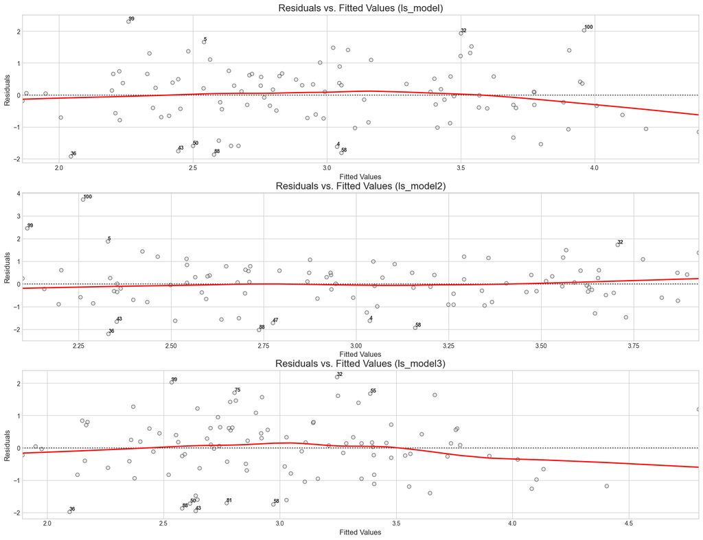

```python
fig, axes = plt.subplots(3,1, figsize=(20,15));

plot_residuals(ls_model, axes[0], title=f'{title} (ls_model)', x_label=x_label, y_label=y_label);
plot_residuals(ls_model2, axes[1], title=f'{title} (ls_model2)', x_label=x_label, y_label=y_label);
plot_residuals(ls_model3, axes[2], title=f'{title} (ls_model3)', x_label=x_label, y_label=y_label);

plt.show()
```

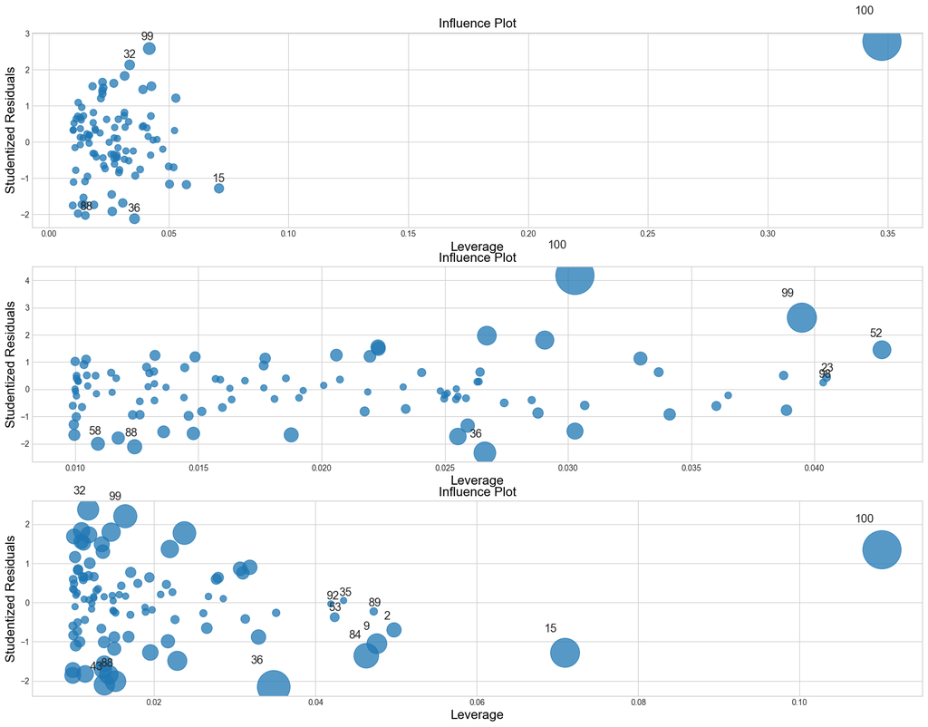

```python
fig, axes = plt.subplots(3,1, figsize=(20,15));

sm.graphics.influence_plot(ls_model, ax=axes[0], criterion="cooks")
sm.graphics.influence_plot(ls_model2, ax=axes[1], criterion="cooks")
sm.graphics.influence_plot(ls_model3, ax=axes[2], criterion="cooks")

plt.show()
```